# 第3回 美人投票を開けて読む

経済プログラミング特論II

第3回

美人投票を開けて読む

平均の変化と、一人ひとりの変化

経済プログラミング特論II

第3回 — Topic01

回答分布と戦略的相互依存

平均の奥にある、一人ひとりの数

## 今日の道のり

1

中身を開ける

演習 1-1・1-2

目標値と分布

2

一人ずつの変化

演習 2-1

上げ下げと平均

3

ルールで書く

演習 3-1・3-2

ルールと level-k

4

言える範囲

演習 4-1・4-2

識別と比較群

平均の奥にある、一人ひとりの数

## 第1回の振り返り

2026年度のデータ

前回までのポイント — 第1回「実験経済学とデータ記録」

第1回の美人投票は、どんなルールだったか

0〜100 の整数を 1 つ選ぶ。全員の平均 × 2/3（目標値）にいちばん近い数が勝ち

R1（1 回目）：平均 43.38・目標値 28.92  
R2（平均と目標値を見た後の 2 回目）：平均 34.58・目標値 23.05

教室に映したのは平均と目標値だけ。今日はその回答を開けて読む

## 目標値と勝ちの定義と求め方

問い：自分の数を変えていないのに、負けることはあるか

定義

**目標値**＝全員の数の平均 × 2/3

**勝ち**＝目標値にいちばん近い数の人（同じ近さなら全員）

手順

STEP 1全員の数を足して、人数で割る（平均）

STEP 2平均に 2/3 を掛ける（目標値）

STEP 3目標値との差がいちばん小さい数を探す（勝ち）

差＝2 つの数の離れ具合（大きいほうから小さいほうを引く）

## STEP 1〜3 8 人の勝ち

8 人の例（教室の数ではない）。STEP 1 の合計：15＋22＋28＋33＋38＋45＋55＋80＝316

[figure not shown]

**目標値 26.33 との差がいちばん小さい 28 が勝ち**

## 1 人の変更と勝ちの移動

同じ 8 人で、80 の人だけが 0 に変える。ほかの 7 人はそのまま

前：合計 316・平均 39.5 → 後：合計 236・平均 236 ÷ 8＝29.5

[figure not shown]

**28 の人は数を変えていないのに、勝ちは 22 へ移った**

## 戦略的相互依存の定義

問いの答え：ある。数を変えていない 28 の人が負けた

定義

**戦略的相互依存**  
＝自分の勝ち負けがほかの人の数でも決まること

- **美人投票では**：目標値は全員の数から出る。  
  だから勝てる数も全員の数で動く
- **読み合い**：ほかの人も、ほかの人の数を読んで選ぶ

## 分析対象集団の定義

2026年度のデータ

今度は第1回の教室の数。R1 の CSV は 57 行のうち教室 52 行

定義

**分析対象集団**＝分析に入れる回答の集まり

**今回**＝第1回の教室で、授業中に送った回答（52 行）

57 行の抜粋。section＝教室か動画／status＝送った時／value＝選んだ数

| 何行目 | section | status | value | 入れるか（説明用） |
| --- | --- | --- | --- | --- |
| 1 | 教室 | 授業内 | 20 | 入れる |
| 2 | 教室 | 授業内 | 48 | 入れる |
| 53 | 動画 | 要確認 | 53 | 入れない |
| 54 | 動画 | 授業後 | 100 | 入れない |

ほかの 5 行（動画）は入れない。確認問題を間違えた人も外さない

## 教室の R1 の平均と目標値

2026年度のデータ

52 行の数を、8 人の例と同じ STEP 1・2 で読む

[figure not shown]

第1回に映した平均と目標値と同じ。誰が勝ったかは出さない

## 目標値の写経

manaba のノート lecture03_beauty_open.ipynb を Colab で開き、「目標値の写経」の下に写す

```python
import pandas as pd
r1 = pd.Series([15, 22, 28, 33, 38, 45, 55, 80])
mean = r1.mean()
target = mean * 2 / 3
print("平均:", round(mean, 2), " 目標値:", round(target, 2))
```

| 行 | 部品 | 渡すもの | 返ってくるもの |
| --- | --- | --- | --- |
| 1 | **① 準備** | `pd` の名前で | 表の道具 pandas が使える |
| 2 | **② データ** | 8 人の数を `[ ]` に | 1 列の表 `r1` |
| 3 | **③ 平均** | `r1` に `.mean()` | 平均 39.5 が `mean` に |
| 4 | **④ 目標値** | `mean` に `* 2 / 3` | 26.33… が `target` に |
| 5 | **⑤ 表示** | `round(数, 2)` | 小数第 2 位までの 2 つの数 |

⏸ PAUSE 動画を止めて $2$ 分。2 つの数が出たら再生に戻る

## CSV への 1 か所の変更

```python
import pandas as pd
r1_all = pd.read_csv("lecture03_beauty_R1.csv")
room = r1_all["section"] == "教室"
inclass = r1_all["status"] == "授業内"
r1 = r1_all[room & inclass]["value"]
mean = r1.mean()
target = mean * 2 / 3
print("平均:", round(mean, 2), " 目標値:", round(target, 2))
```

| 行 | 部品 | 前の写経から変えた部品 |
| --- | --- | --- |
| 2 | **② 読む** | `pd.read_csv("名前")`＝CSV の全部の行を表 `r1_all` に |
| 3-4 | **② 印を付ける** | `==`＝等しいか。行ごとに True（はい）か False |
| 5 | **② 絞る** | `&`＝両方が True の行（52 行）。`["value"]`＝選んだ数の列 |

※ 6〜8 行目は変えない。文字は半角の `"` で囲む。CSV は manaba にある

## CSV のアップロードと実行

2026年度のデータ

1. 左の列のフォルダの  
   印を押す
2. **上向き矢印の印**で R1 の  
   CSV を選ぶ
3. **＋ コード**でセルを足し、  
   p.12 の 8 行を写して **▶**
4. 出た平均と目標値の 2 つ  
   の数を見る

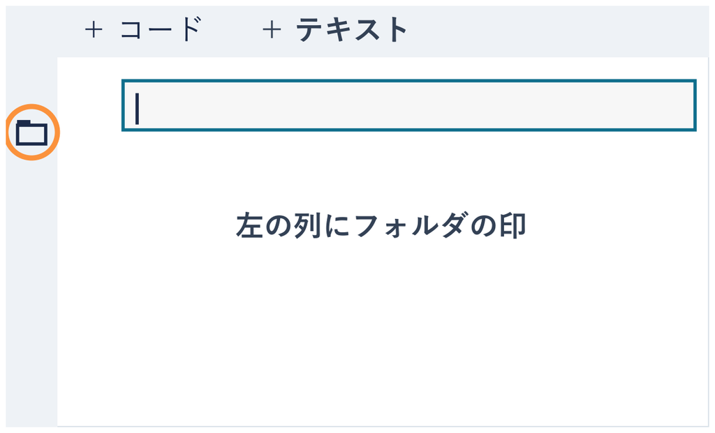

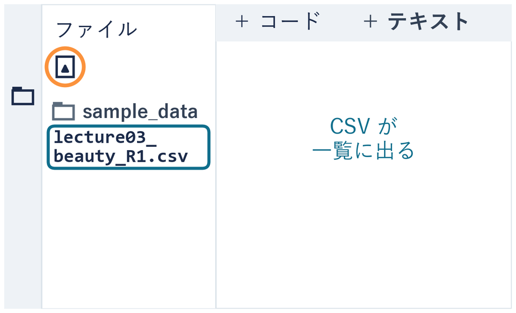

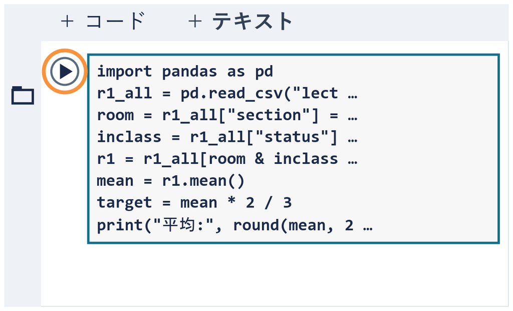

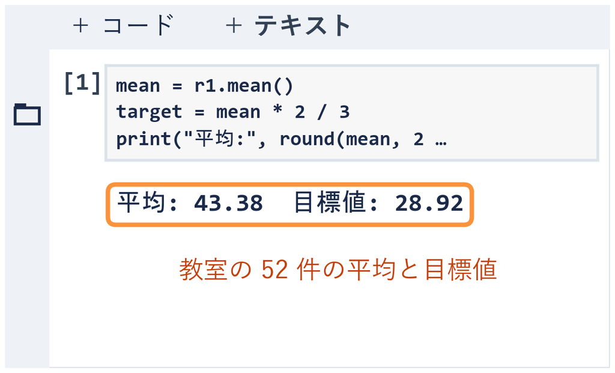

⏸ PAUSE 動画を止めて $3$ 分。平均と目標値が出たら再生に戻る

## 演習 1-1 80 から 100 への変更

演習 1-1

8 人の例で、80 の人が 100 に変える。目標値と勝ちはどうなるか

```python
import pandas as pd
r1 = pd.Series([15, 22, 28, 33, 38, 45, 55, 80])
mean = r1.mean()
target = mean * 2 / 3
print("平均:", round(mean, 2), " 目標値:", round(target, 2))
```

1. **先に考える**：勝ちは ⓐ 28 のまま ⓑ 33 に移る ⓒ 22 に移る
2. **新しいセルで変える**：5 行を写し（コピー可）、80 を 100 に
3. **終わり**：目標値が出て、いちばん近い数が言えたら

⏸ PAUSE 動画を止めて $3$ 分。目標値が出たら再生に戻る

## 演習 1-1 の答え

答えは ⓐ。部品を前から 1 つずつ比べる

平均

$39.5$

$\to 42$

合計が 20 増え、8 人で割ると 2.5 増える

目標値

$26.33$

$\to 28$

$42 \times 2/3 = 28$

28 との差

$1.67$

$\to 0$

目標値がちょうど 28 に来た

勝ち

$28$

$\to 28$

差 0 より近い数は無い

目標値が動いても、勝ちが変わらないこともある

## 回答分布の定義と作り方

問い：平均が同じ 2 つのクラスは、同じような数を選んだと言えるか

定義

**区切り**＝件数を数える枠（0〜9、10〜19、…、90〜100）

**回答分布**＝区切りごとの回答の件数。棒で描くとヒストグラム

手順

STEP 1区切りを決める（10 ずつ）

STEP 21 件ずつ、その数が入る区切りに積む

STEP 3積んだ件数を、棒の高さにする

数えて積むだけ（最後の区切りだけ 100 も入る）

## STEP 1〜3 平均が同じ 2 クラス

A は 8 人の例、B は 35〜44 に集まった 8 人。どちらも平均 39.5

[figure not shown]

**平均の線は同じ所なのに、山の形は違う**

## 教室の R1 と R2 の回答分布

2026年度のデータ

今度は第1回の教室の数。R1 と R2 を同じ区切りで積む

[figure not shown]

R1 の山は 30〜39。R2 は左へ寄り、10〜19 に 13 件の山

## ヒストグラムの写経

```python
!pip install japanize-matplotlib
import japanize_matplotlib
import pandas as pd
import matplotlib.pyplot as plt
r2_all = pd.read_csv("lecture03_beauty_R2.csv")
room = r2_all["section"] == "教室"
inclass = r2_all["status"] == "授業内"
r2 = r2_all[room & inclass]["value"]
plt.hist(r2, bins=range(0, 101, 10))
plt.xlabel("選んだ数")
plt.ylabel("件数")
plt.show()
```

| 行 | 部品 | 中身 |
| --- | --- | --- |
| 1-2 | **① 準備** | Colab で日本語を出す 2 行（同じノートでは一度でよい） |
| 3-4 | **① 準備** | 表の道具 pandas と、図の道具 `plt` |
| 5-8 | **② データ** | 目標値のセルと同じ 4 行。ファイルは R2 |
| 9 | **③ 棒を積む** | 境目 0, 10, …, 100 を `range` で渡す |
| 10-12 | **④ 軸と表示** | 横と縦に名前を付けて、図を出す |

## ヒストグラムの写経と実行

2026年度のデータ

1. R2 の CSV も、フォルダ  
   の印からアップロード
2. **＋ コード**でセルを足し、  
   p.19 の 12 行を写す
3. **▶** か **Shift + Enter** で実行  
   （Mac は Shift + return）
4. 10〜19 の棒の高さ 13  
   （目盛り 12 と 14 の  
   間）を見る

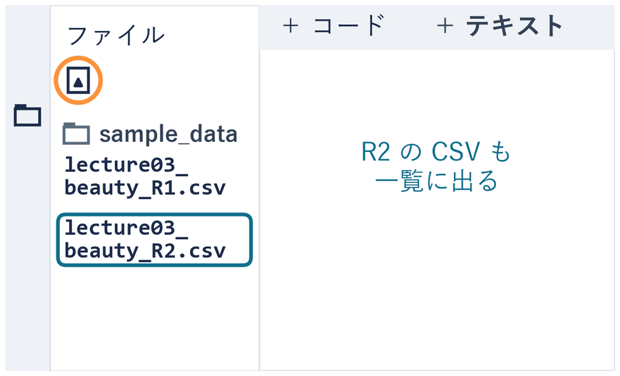

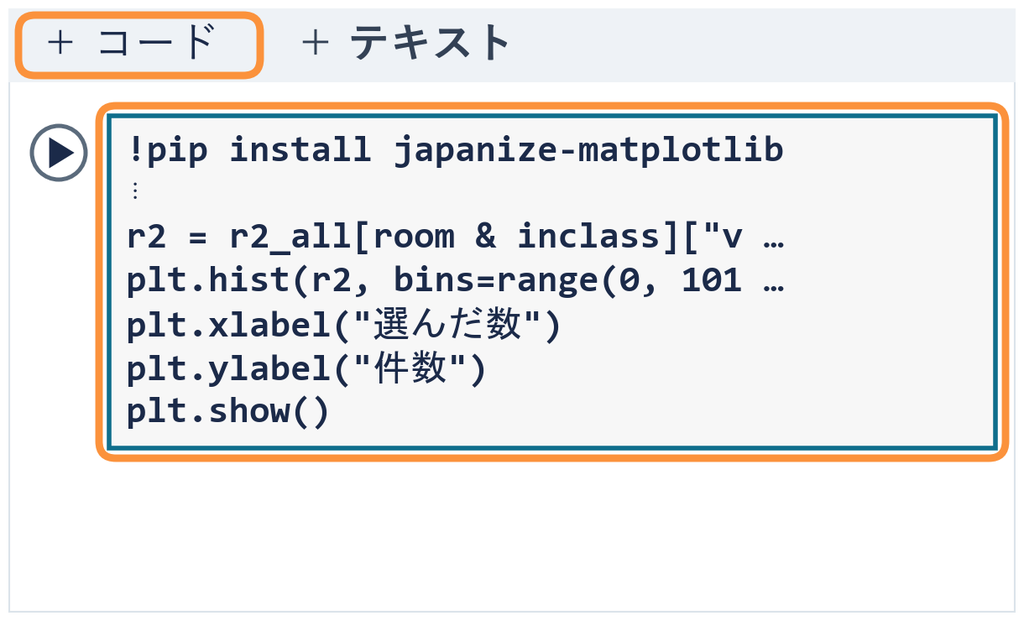

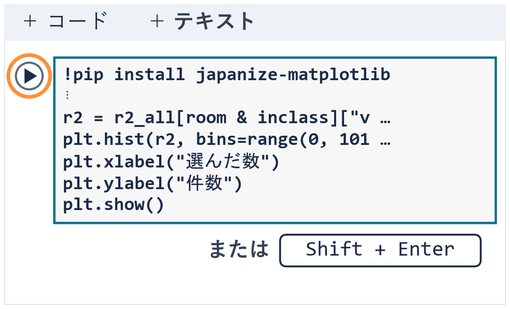

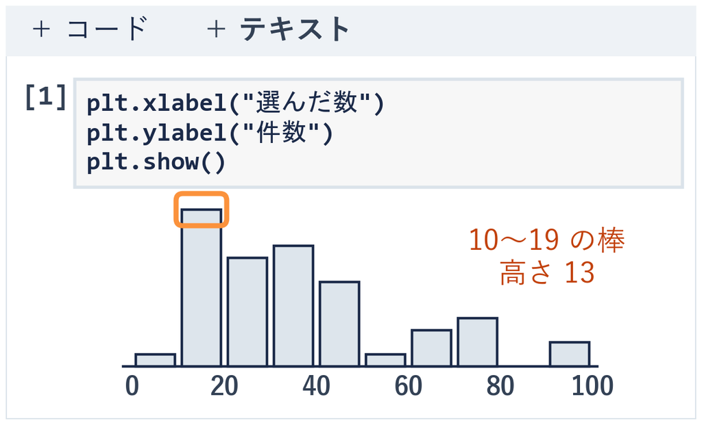

⏸ PAUSE 動画を止めて $3$ 分。図が出たら再生に戻る

## 演習 1-2 区切りの幅の変更

2026年度のデータ

演習 1-2

区切りを 20 ずつにする。20〜39 の棒は何件になるか

```python
plt.hist(r2, bins=range(0, 101, 10))
```

1. **先に考える**：ⓐ 9 件 ⓑ 19 件 ⓒ 50 件
2. **新しいセルで変える**：p.19 の 12 行を写し（コピー可）、  
   9 行目の `range` の 10 を 20 に
3. **終わり**：図が出て、20〜39 の棒の高さが読めたら

⏸ PAUSE 動画を止めて $3$ 分。図が出たら再生に戻る

## 演習 1-2 の答え

2026年度のデータ

答えは ⓑ。10 ずつの 2 本が、20 ずつの 1 本にまとまる

[figure not shown]

同じ 50 件でも、区切りの幅で山の見え方が変わる

## まとめ

- **目標値と勝ち**：平均 × 2/3 にいちばん近い数が勝ち
- **戦略的相互依存**：自分の数を変えなくても、  
  ほかの人の数で勝ち負けが動く
- **分析対象集団**：第1回の教室で、授業中に送った回答
- **回答分布**：区切りごとの件数。平均が同じでも、山の形は違う

次は、一人ひとりが R1 から R2 へどう動いたか

経済プログラミング特論II

第3回 — Topic02

集団平均の変化と個人差

平均が下がっても、みんなが下げたとは限らない

## 今日の道のり

1

分布を開ける

演習 1-1・1-2

目標値と分布

2

一人ずつの変化

演習 2-1

上げ下げと平均

3

ルールで書く

演習 3-1・3-2

ルールと level-k

4

言える範囲

演習 4-1・4-2

識別と比較群

平均の動きと、一人ずつの動きを分けて見る

## ✋ たしかめ 4 人の上げ下げ

4 人のクラス（人工例）。平均は 1 回目の 35 から、2 回目の 18.75 に下がった

たしかめ

一人ひとりは、どう動いたか

ⓐ 4 人とも下げた ⓑ 下げた人が多い ⓒ 平均からは分からない

1. 予想を ⓐ〜ⓒ から 1 つ選ぶ
2. 平均の数だけで、一人ずつの向きが決まるか、で考える

⏸ PAUSE 動画を止めて $1$ 分。予想を決めたら再生に戻る

## 4 人の線と上げ下げの数

✕ 平均が下がったのだから、みんな下げた

[figure not shown]

**答えは ⓒ。1 人の下げ幅 80 が、3 人の上げ幅を合わせた 15 より大きい**

## 対応のある比較の定義と数え方

定義

**対応のある比較**＝同じ人の 2 つの数を、1 行ずつ比べること

**1 行ずつの差**＝2 回目 − 1 回目。＋なら上げた、−なら下げた

**変化の平均**＝1 行ずつの差の合計 ÷ 人数

手順

STEP 1同じ人の 1 回目と 2 回目を、1 行に並べる

STEP 21 行ずつ差をとる

STEP 3差の＋・−で、上げた・下げた・同じ（0）を数える

平均の動きは 1 つの数。一人ずつの向きは、1 行ずつの差で数える

## デモ：平均と一人ずつの変化

数の話

このデモの数は、線1本＝R2 フォームの1行  
（自己申告 R1 → R2）。上げた・下げた・同じを数える

- **何を見るか**：平均が下がっても、上がる線は何本あるか
- **図の意味**：左＝一人ずつの線と平均／右＝平均・変化・件数
- **操作**：止めて3分。配布のデモでタブを押し、線を表示する

ミッション 上がった・ほぼ同じのタブで、  
上げた人の数を予想してから「線を表示」を押す

※ 次のスライドへ進むときは、デモの枠の外を一度クリックしてから ← → キーを押す

[interactive chart not shown]

## ミッションの答え 3 つのタブの線

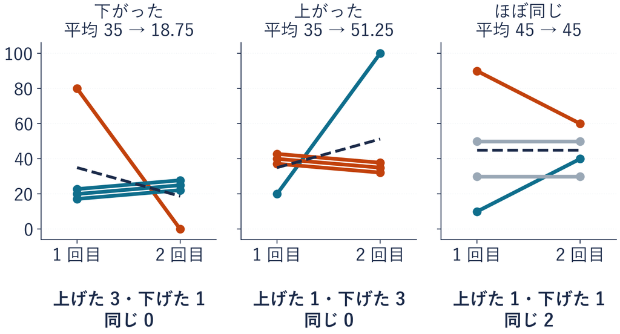

上がった：1 人が 20 → 100（+80）、3 人が 40 → 35（−5）  
ほぼ同じ：10 → 40（+30）と 90 → 60（−30）が動いた

平均が上がっても 3 人は下げ、平均が同じでも 2 人は動いた

## R2 フォームの行と自己申告 R1

2026年度のデータ

今度は第1回の教室の数。R2 フォームの 1 行に、2 つの数が並ぶ

| 行 | self_r1（1 回目） | value（2 回目） | 差 |
| --- | --- | --- | --- |
| 1 | 40 | 30 | −10 |
| 2 | 20 | 20 | 0 |
| 3 | 1 | 10 | +9 |
| ⋮ | ⋮ | ⋮ | ⋮ |
| 42 | 0 | 100 | +100 |
| ⋮ | ⋮ | ⋮ | ⋮ |
| 50 | 50 | 30 | −20 |

**自己申告 R1**＝R2 フォームに自分で書いた 1 回目の数

**記録の点検**＝R1 フォームの記録と合うかの確かめ。合うとは限らない

**空欄の行**＝線にできないので外す（今回の 50 行には 0 行）

## 教室の 50 行の上げ下げ

2026年度のデータ

4 人と同じ STEP 1〜3。今回は空欄が 0 行だったので、50 行すべてが残る

[figure not shown]

**平均は下がったのに、上げた人が 15 人いる**

## 上げ下げの数の写経

```python
form = pd.DataFrame({"self_r1": [80, 20, 20, 20],
                     "value": [0, 25, 25, 25]})
pairs = form.dropna(subset=["self_r1"])
change = pairs["value"] - pairs["self_r1"]
print("1 回目の平均", round(pairs["self_r1"].mean(), 2))
print("2 回目の平均", round(pairs["value"].mean(), 2))
print("上げた", (change > 0).sum())
print("下げた", (change < 0).sum())
print("同じ", (change == 0).sum())
```

| 行 | 部品 | 渡すもの | 返ってくるもの |
| --- | --- | --- | --- |
| 1-2 | **① 表を作る** | 列の名前と `[ ]` の数 | 4 行の表 `form` |
| 3 | **② 空欄を外す** | 列の名前 `"self_r1"` | 空欄の無い表 `pairs` |
| 4 | **③ 1 行ずつの差** | 2 回目の列 − 1 回目の列 | 差の列 `change` |
| 5-6 | **④ 2 つの平均** | 列ごとの `.mean()` | 1 回目と 2 回目の平均 |
| 7-9 | **⑤ 数える（同じ形）** | `>`・`<`・`==` で True／False | `.sum()`＝True の数 |

## 上げ下げの数の写経と実行

1. **＋ コード**で空の  
   セルを足す
2. p.34 の 9 行を上から写す
3. **▶** か **Shift + Enter** で実行  
   （Mac は Shift + return）
4. 平均が下がり、上げたが  
   3 と出るのを見る

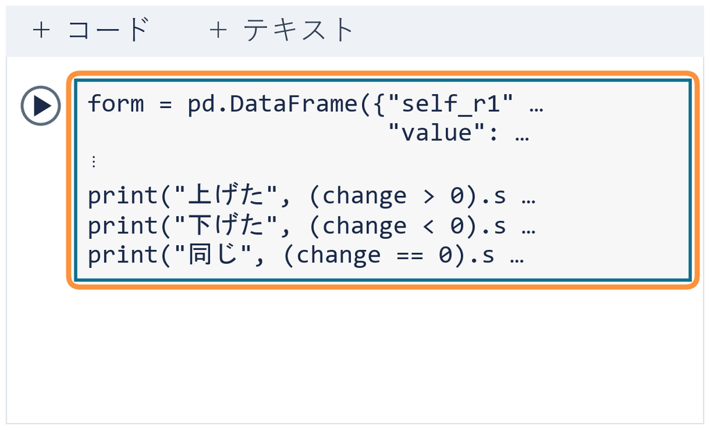

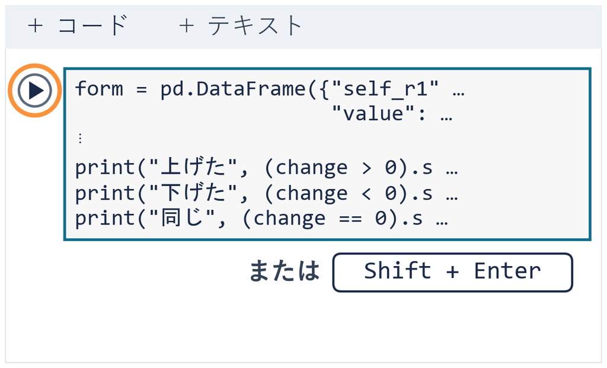

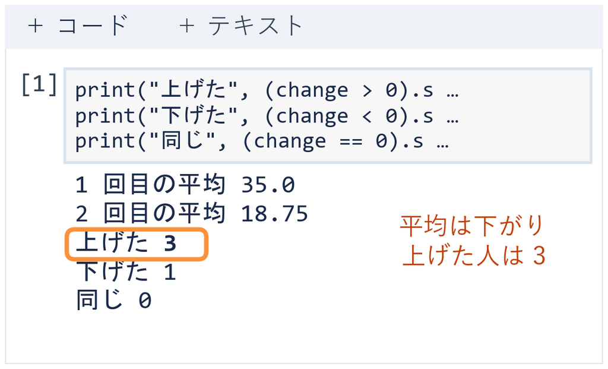

⏸ PAUSE 動画を止めて $3$ 分。5 行が出たら再生に戻る

## 教室の行への変更

2026年度のデータ

```python
r2_all = pd.read_csv("lecture03_beauty_R2.csv")
room = r2_all["section"] == "教室"
inclass = r2_all["status"] == "授業内"
form = r2_all[room & inclass]
pairs = form.dropna(subset=["self_r1"])
change = pairs["value"] - pairs["self_r1"]
print("1 回目の平均", round(pairs["self_r1"].mean(), 2))
print("2 回目の平均", round(pairs["value"].mean(), 2))
print("上げた", (change > 0).sum())
print("下げた", (change < 0).sum())
print("同じ", (change == 0).sum())
```

| 行 | 部品 | 前の写経から変えた部品 |
| --- | --- | --- |
| 1-4 | **① 表を作る** | 前のトピックと同じ 4 行で、 R2 の教室・授業内を `form` に |

⏸ PAUSE 動画を止めて $2$ 分。1〜2 行目を 4 行に替えて実行

## 演習 2-1 平均が下がる境目

演習 2-1

A の 2 回目がいくつ未満なら、平均は下がるか

```python
form = pd.DataFrame({"self_r1": [80, 20, 20, 20],
                     "value": [0, 25, 25, 25]})
```

1. **先に考える**：ⓐ 35 未満 ⓑ 65 未満 ⓒ 80 未満
2. **新しいセルで変える**：p.34 の 9 行を写し（コピー可）、  
   2 行目の `0` だけを `64` と `65` に
3. **終わり**：`2 回目の平均` が 35 より小さいかを、2 回とも見たら

⏸ PAUSE 動画を止めて $3$ 分。2 回の数が出たら再生に戻る

## 演習 2-1 の答え

答えは ⓑ 65 未満。平均の 35 から 1 段ずつ戻す

平均

$35 \times 4$

$= 140$

2 回目の合計が 140 未満なら下がる

B・C・D

$25 \times 3$

$= 75$

3 人の合計

A

$140 - 75$

$= 65$

A は 65 未満

64 なら

$(64 + 75) \div 4$

$= 34.75$

35 より小さい・上げた 3 のまま

A の下げ幅 16 だけで、3 人の上げ幅を合わせた 15 を上回る

## まとめ

- 平均が下がっても、全員が下げたとは限らない
- 対応のある比較：同じ人の 2 つの数を、1 行ずつ比べる
- 1 行ずつの差の＋・−で、上げた・下げた・同じを数える
- 平均という 1 つの数からは、上げた人が見えない

誰がどう動いたかは数えられた。次は、なぜそう選んだか

経済プログラミング特論II

第3回 — Topic03

行動ルールと level-k モデル

読み合いを、ルールとして書く

## 今日の道のり

1

分布を開ける

演習 1-1・1-2

目標値と分布

2

一人ずつの変化

演習 2-1

上げ下げと平均

3

ルールで書く

演習 3-1・3-2

ルールと level-k

4

言える範囲

演習 4-1・4-2

識別と比較群

誰が動いたかは数えた。選んだ理由の候補を、選び方の決まりとして書く

## 行動ルールの定義と 3 つの例

問い：同じ平均を見たのに、選ぶ数が人によって違うのはなぜか

定義

**行動ルール**＝入力から、出力（選ぶ数）を返す決まり

**入力**＝選ぶ前に見た数（自分の R1 の数・見た平均）

3 つの例

固定前の自分の数を、そのまま出す

追随見た平均と同じ数を出す

一定倍見た平均 × 2/3 を出す（目標値と同じ作り方）

ルールに書くと、同じ入力で計算して比べられる

## 3 つのルールの出力 同じ入力

今回は、前の自分の数 50・見た平均 39.5（前に出てきた 8 人の平均）

[figure not shown]

**同じ入力でも、ルールが違えば出力が違う**

※ 出力はルールの出す数。実際に書くのは近い整数

## 教室の R2 と 2 つのルールの縦線

2026年度のデータ

今度は第1回の教室。R2 の前に見た平均 43.38 → 追随 43.38・一定倍 28.92

[figure not shown]

R2 の山（10〜19 に 13 件）は 2 本の線より左。固定と同じ出力は 50 行中 4 行

## 3 つの出力の写経

```python
prev = 50
shown = r1.mean()
print("固定", prev)
print("追随", round(shown, 2))
print("一定倍", round(shown * 2 / 3, 2))
```

| 行 | 部品 | 渡すもの | 返ってくるもの |
| --- | --- | --- | --- |
| 1-2 | **① 入力を置く** | 50 と `r1.mean()` | 名前 `prev`・`shown` |
| 3 | **② 固定** | `prev` | 50 のまま |
| 4 | **③ 追随** | `shown` | 43.38 |
| 5 | **④ 一定倍** | `shown * 2 / 3` | 28.92 |

※ 3〜5 行目は同じ形。`round(数, 2)`＝小数第 2 位まで・`*` 掛ける・`/` 割る  
※ `r1`（R1 の教室の行）は p.12 のセルで作る。演習 1-1 の後は p.12 を再実行  
※ 出力はルールの出す数。実際に書くのは近い整数

## 3 つの出力の写経と実行

1. **＋ コード**で空の  
   セルを足す
2. p.45 の 5 行を上から写す
3. **▶** か **Shift + Enter** で実行  
   （Mac は Shift + return）
4. 3 つのルールの  
   出力を見る

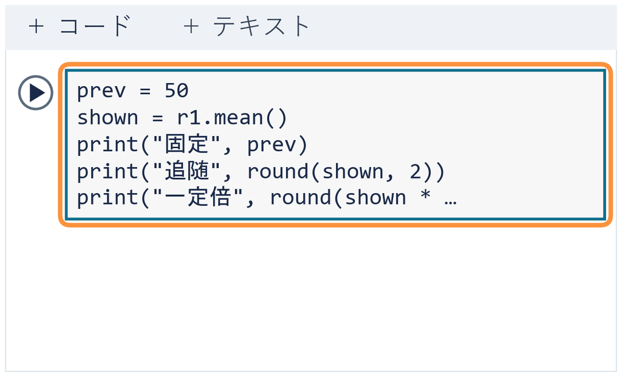

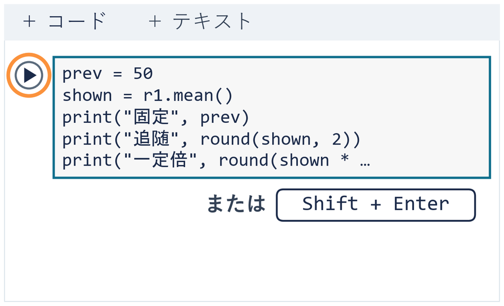

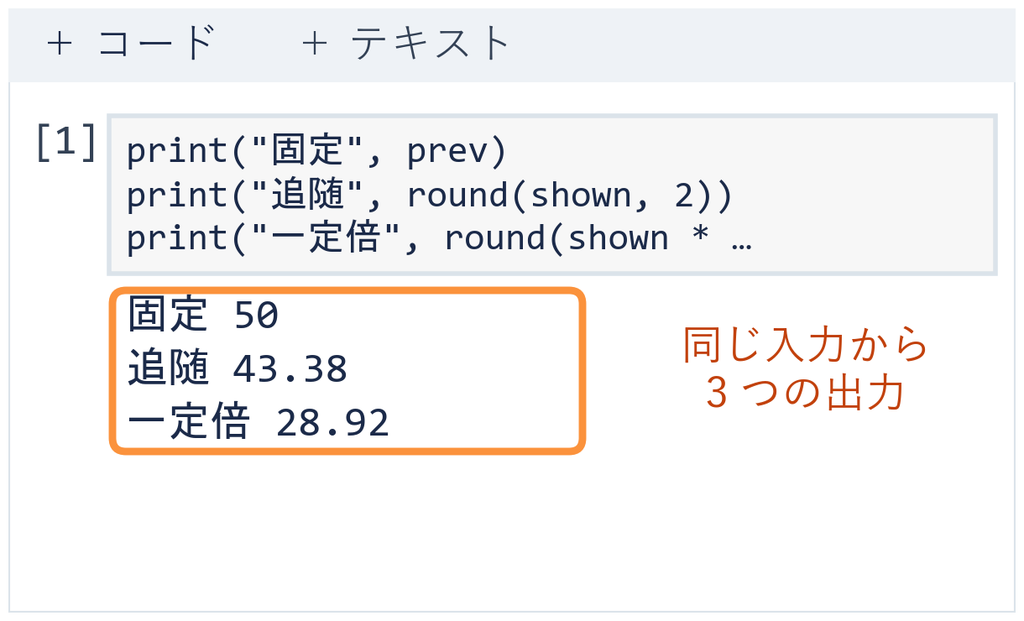

⏸ PAUSE 動画を止めて $2$ 分。3 行が出たら再生に戻る

## R2 のヒストグラムへの縦線の追加

2026年度のデータ

```python
prev = 50
shown = r1.mean()
print("固定", prev)
print("追随", round(shown, 2))
print("一定倍", round(shown * 2 / 3, 2))
plt.hist(r2, bins=range(0, 101, 10))
plt.axvline(shown)
plt.axvline(shown * 2 / 3)
plt.show()
```

| 行 | 部品 | 前の写経から変えた部品 |
| --- | --- | --- |
| 1-5 | **①〜④** | p.45 と同じ 5 行（入力 `shown` は `r1.mean()` のまま） |
| 6-9 | **⑤ 縦線** | ヒストグラムに `plt.axvline(数)` で縦線を 2 本 |

※ `r2`・`plt` は p.19 のセルで作る

⏸ PAUSE 動画を止めて $2$ 分。3 行と図が出たら再生に戻る

## 演習 3-1 見た平均の変更

演習 3-1

見た平均が 60 になると、出力が動かないルールはどれか

```python
prev = 50
shown = r1.mean()
print("固定", prev)
print("追随", round(shown, 2))
print("一定倍", round(shown * 2 / 3, 2))
```

1. **先に考える**：ⓐ 固定 ⓑ 追随 ⓒ 一定倍
2. **新しいセルで変える**：5 行を写し、2 行目の `r1.mean()` を `60` に
3. **終わり**：3 行を、写経の出力と見比べたら

⏸ PAUSE 動画を止めて $2$ 分。3 行が出たら再生に戻る

## 演習 3-1 の答え

答えは ⓐ 固定。ルールが入力のどれを使うかを、1 つずつ見る

入力

$43.38$

$\to 60$

変えたのは見た平均だけ

固定

$50$

$\to 50$

見た平均を使わない

追随

$43.38$

$\to 60$

見た平均そのもの

一定倍

$60 \times 2 \div 3$

$= 40$

前は $43.38 \times 2 \div 3 \approx 28.92$

使う入力が変わったルールだけ、出力が動く

## level-k モデルの定義と求め方

定義

**level-0**＝読まずに選ぶ人。50 とおく（データでなく仮定）

**level-k**＝ほかの人を全員 1 段手前と見て、その 2/3 を選ぶ人

例：level-1 は、他の全員が level-0 なら平均 50（自分は無視）。50 × 2/3 で 33.33

手順

STEP 1level-0 を 50 とおく

STEP 22/3 を掛けて、1 段上の値にする

STEP 3STEP 2 をくり返す（k 段読むなら k 回）

✕ level-1 ＝ 見た平均の 2/3 → この回の level-k は level-0＝50 から始める

## STEP 1〜3 level-0 50 から 3 段

今回は level-0 が 50。STEP 2 は $50 \times \tfrac{2}{3} \approx 33.33$

[figure not shown]

**1 段読むごとに、選ぶ数は 2/3 に小さくなる**

## 教室の R2 と level の縦線

2026年度のデータ

今度は教室の R2。整数で答えたので、いちばん近い整数で数える

[figure not shown]

縦線の数と同じ整数を書いたのは、22 の 1 行だけ  
それでも、ルールを書くと比べる物差しになる

## level-k の写経

```python
level = 50
for k in range(1, 4):
    level = level * 2 / 3
    print("level", k, round(level, 2))
```

| 行 | 部品 | 渡すもの | 返ってくるもの |
| --- | --- | --- | --- |
| 1 | **① level-0 を置く** | 50 | 名前 `level` |
| 2 | **② 3 回くり返す** | `range(1, 4)`＝1・2・3 | `k` に 1 つずつ入る |
| 3 | **③ 1 段上げる** | `level * 2 / 3` | 新しい `level`（上書き） |
| 4 | **④ 表示** | 段の番号 `k` と値 | 1 段ごとに 1 行 |

※ 2 行目の終わりのコロン `:` も写す  
※ 字下げ（半角スペース 4 つ）した 3〜4 行目が、くり返す範囲

## level-k の写経と実行

1. **＋ コード**で空の  
   セルを足す
2. p.53 の 4 行を写す  
   （字下げも）
3. **▶** か **Shift + Enter** で実行  
   （Mac は Shift + return）
4. level 1〜3 の 3 行を見る

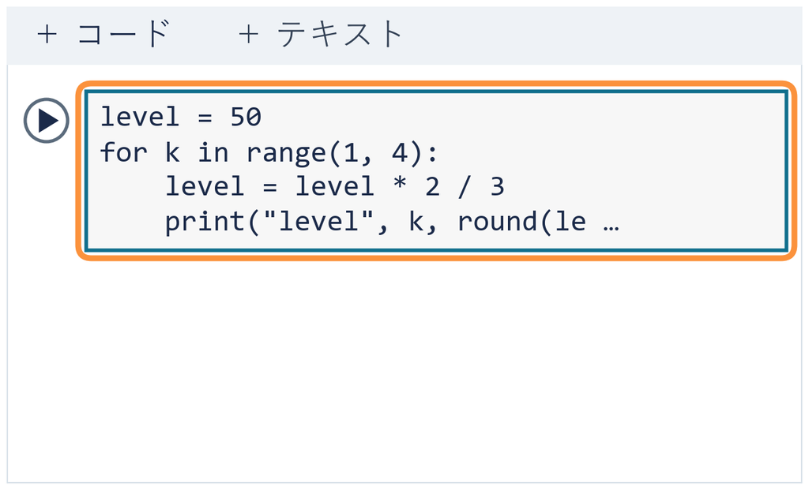

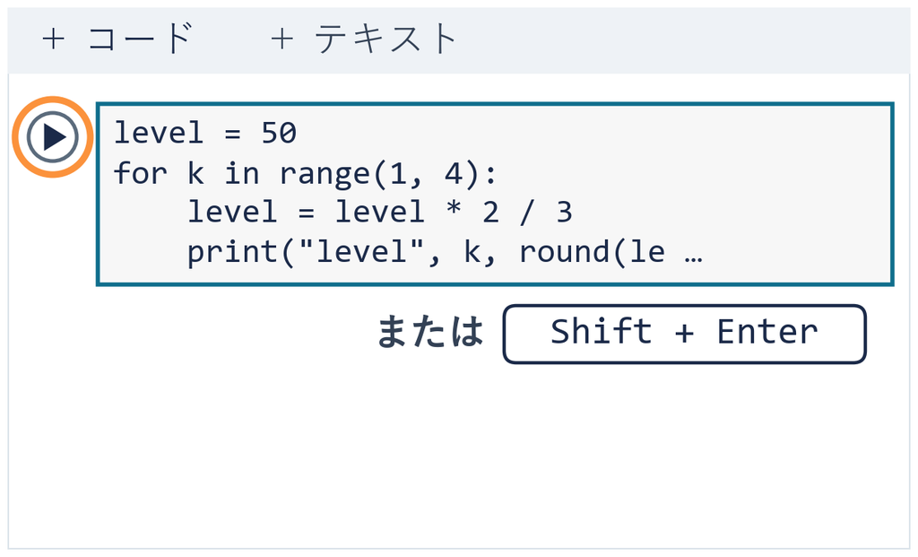

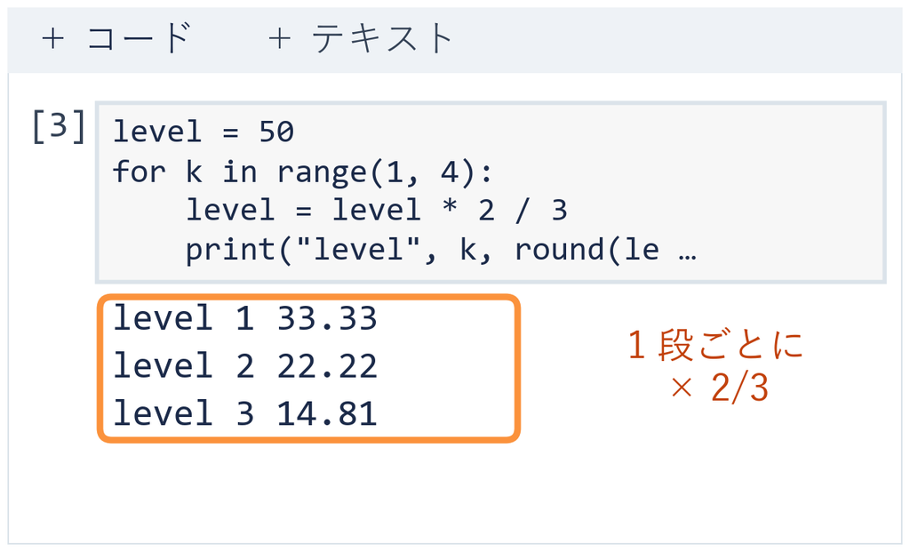

⏸ PAUSE 動画を止めて $2$ 分。3 行が出たら再生に戻る

## 教室の R2 への変更

2026年度のデータ

```python
level = 50
for k in range(1, 4):
    level = level * 2 / 3
    print("level", k, round(level), "の行", (r2 == round(level)).sum())
    plt.axvline(level)
plt.hist(r2, bins=range(0, 101, 10))
plt.show()
```

| 行 | 部品 | 前の写経から変えた部品 |
| --- | --- | --- |
| 4 | **④ 表示** | `round(level)`＝いちばん近い整数 `(r2 == round(level)).sum()` ＝その整数と同じ数の行の数 |
| 5-7 | **⑤ 縦線** | 段ごとに `plt.axvline(level)`、最後にヒストグラム |

⏸ PAUSE 動画を止めて $2$ 分。3 行と図が出たら再生に戻る

## 演習 3-2 level-0 の変更

演習 3-2

level-0 を 90 とおくと、level-3 はいくつか

```python
level = 50
for k in range(1, 4):
    level = level * 2 / 3
    print("level", k, round(level, 2))
```

1. **先に考える**：ⓐ 14.81 のまま ⓑ 26.67 ⓒ 40
2. **新しいセルで変える**：1 行目の `50` だけを `90` に
3. **終わり**：level 3 の値が出たら

⏸ PAUSE 動画を止めて $2$ 分。3 行が出たら再生に戻る

## 演習 3-2 の答え

答えは ⓑ 26.67。STEP どおりに 1 段ずつたどる

level-0

$90$

変えたのは出発点だけ

level-1

$90 \times \tfrac{2}{3}$

$= 60$

STEP 2

level-2

$60 \times \tfrac{2}{3}$

$= 40$

STEP 3（くり返し）

level-3

$40 \times \tfrac{2}{3}$

$\approx 26.67$

50 のときの 14.81 とは別の数

## まとめ

- 行動ルール：入力（見た情報）から、出力（選ぶ数）を返す決まり
- 同じ入力でも、固定・追随・一定倍で出力が違う
- level-k：level-0 を 50 とおき、1 段読むごとに 2/3 を掛ける
- 段を続けると、選ぶ数は 0 に近づいていく
- ルールの出力は計算で決まる。人が選んだ数はデータで決まる

選んだ理由の候補は書けた。では、22 と書いた人は 2 段読んだと言えるか

経済プログラミング特論II

第3回 — Topic04

識別と因果推論の限界

なぜ動いたかは、線だけでは分からない

## 今日の道のり

1

中身を開ける

演習 1-1・1-2

目標値と分布

2

一人ずつの変化

演習 2-1

上げ下げと平均

3

ルールで書く

演習 3-1・3-2

ルールと level-k

4

言える範囲

演習 4-1・4-2

識別と比較群

数から言えることと、言えないことを分ける

## ✋ たしかめ 22 と書いた人の読み

level-0 を 50 とおくと、level-2 は 22（前のトピックの表）

たしかめ

22 と書いた人は、2 段読んだのか

ⓐ 2 段読んだ ⓑ 読んでいない ⓒ 数だけでは分からない

1. 予想を ⓐ〜ⓒ から 1 つ選ぶ
2. 22 にたどり着く考え方が、ほかにもあるか、で考える

⏸ PAUSE 動画を止めて $1$ 分。予想を決めたら再生に戻る

## 22 に集まる 3 つの道

✕ 22 を選んだのだから、2 段読んだ

[figure not shown]

**答えは ⓒ。記録に残るのは数だけで、道は残らない**

## 識別の定義と確かめ方

定義

**識別**＝同じ数を生む説明を、データで 1 つに絞ること

**識別できない**＝データだけでは 1 つに絞れないこと

確かめ方

STEP 1その数を生む道（説明）を書き出す

STEP 2道ごとに計算して、同じ数が出るかを見る

STEP 32 つ以上の道で出たら、数だけでは識別できない

データに残るのは選んだ数だけ。考え方は残らない

## 教室で 22 を書いた行の道

2026年度のデータ

今度は第1回の教室の R2。  
level の整数 33・22・15 を書いたのは 22 の 1 行だけ

3 つのルール：固定＝自分の R1 のまま  
追随＝見た平均 43.38 → 43／一定倍＝43.38 × 2/3 → 29

**行 29：26 → 22**level-2 の道はある。3 つのルールでは出ない（固定なら 26）

**同じ行 29**まねた・なんとなく でも、22 は書ける

1 行でも、道は 2 つ以上。数だけでは 1 つに決められない

## 2 つの道の計算の写経

```python
level2 = round(50 * 2/3 * 2/3)
rule = round(33 * 2/3)
print("level-2 の道", level2)
print("一定倍の道", rule)
print("同じ数か", level2 == rule)
```

| 行 | 部品 | 渡すもの | 返ってくるもの |
| --- | --- | --- | --- |
| 1 | **① level-2 の道** | 50 と 2/3 を 2 回 | いちばん近い整数 22 |
| 2 | **② 一定倍の道** | 33 と 2/3 を 1 回 | いちばん近い整数 22 |
| 3-4 | **③ 2 つを表示** | 名前と数 | 22 と 22 |
| 5 | **④ 同じか確かめる** | `==`（等しい） | True（同じ）か False |

※ `round(数)` は桁を書かないと、いちばん近い整数を返す

## 2 つの道の写経と実行

1. **＋ コード**で空の  
   セルを足す
2. p.65 の 5 行を上から写す
3. **▶** か **Shift + Enter** で実行  
   （Mac は Shift + return）
4. 22 が 2 つと True が出る  
   のを見る

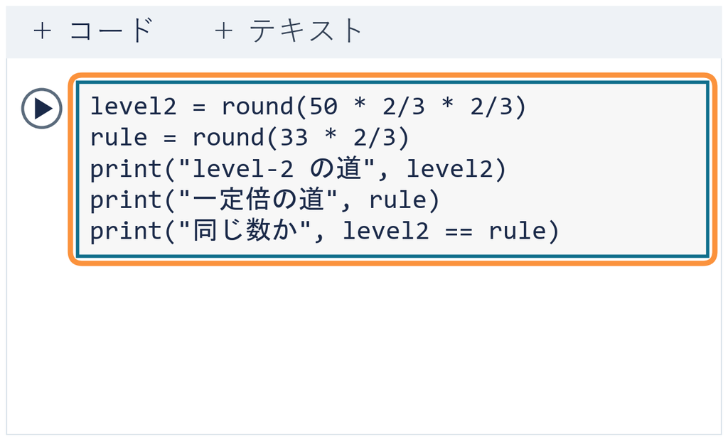

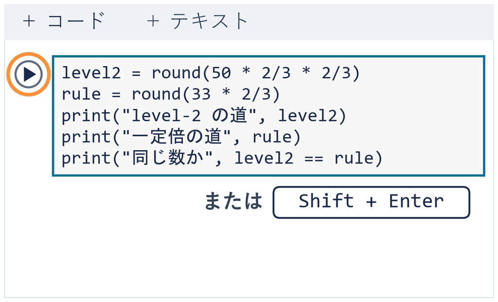

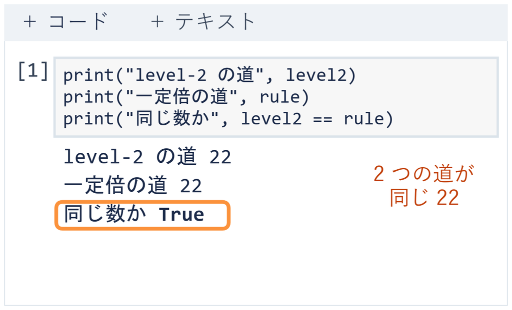

⏸ PAUSE 動画を止めて $2$ 分。3 行が出たら再生に戻る

## 演習 4-1 level-1 と同じ 33

演習 4-1

一定倍の道で level-1 と同じ 33 を出す見た平均は

```python
level1 = round(50 * 2/3)
rule = round(33 * 2/3)
print("level-1 の道", level1)
print("一定倍の道", rule)
print("同じ数か", level1 == rule)
```

1. **先に考える**：ⓐ 40 ⓑ 50 ⓒ 75
2. **新しいセルで変える**：5 行を写し、2 行目の `33` を 3 つの数に順に
3. **終わり**：`同じ数か` が True になる数が見つかったら

⏸ PAUSE 動画を止めて $3$ 分。3 回の数が出たら再生に戻る

## 演習 4-1 の答え

答えは ⓑ 50。50 のときだけ「同じ数か」が True。2 つの道の式を並べる

level-1

$50 \times 2/3$

$\approx 33.33$

level-0 の 50 から 1 段・整数で 33

一定倍（50）

$50 \times 2/3$

$\approx 33.33$

見た平均 50 から・整数で 33

一定倍（40）

$40 \times 2/3$

$\approx 26.67$

整数で 27

一定倍（75）

$75 \times 2/3$

$= 50$

整数でも 50

level-0 を 50 とおく人と、平均 50 を見た人は、同じ式を計算する  
だから 33 という数からは、どちらの道か決められない

## 比較群と因果推論の定義

問い：「平均を見たから下げた」と言うには、誰と比べればよいか

定義

**比較群**＝A が起きなかった人の集まり

**因果推論**＝A が B を起こしたかを、データで確かめること

手順

STEP 1A が起きた人の、変化（2 回目 − 1 回目）の平均を出す

STEP 2比較群の、変化の平均を出す

STEP 3STEP 1 から STEP 2 を引く  
比較群が A のほかはよく似ていれば、残りが A の分と読める

この回では A＝平均を見たこと、B＝2 回目で数が変わったこと

## STEP 1〜3 6 人の 2 本の棒

今回は 6 人（人工例）。全員が 2 回選び、平均を見たのは 3 人だけ

[figure not shown]

**−8 − (−2) ＝ −6。見なかった人の −2 は、2 回目や時間の分**

## 教室の比較群

2026年度のデータ

今度は第1回の教室。50 行の全員が、平均と目標値を見てから R2 を出した

ここは R1 と R2 の両方を書いた同じ人の行だけ。T1 の全体の平均の差とは別  
50 行の変化の平均：差の合計 −460 ÷ 50 ＝ −9.2

[figure not shown]

**引く相手が無いので、−9.2 を 4 つに分けられない**

## 比較群の写経

```python
saw = pd.Series([-10, -8, -6])
not_saw = pd.Series([-4, -2, 0])
print("見た 3 人", saw.mean())
print("見なかった 3 人", not_saw.mean())
print("平均を見た効果", saw.mean() - not_saw.mean())
print("教室の変化の平均", round(change.mean(), 2))
```

| 行 | 部品 | 渡すもの | 返ってくるもの |
| --- | --- | --- | --- |
| 1-2 | **① 2 つの集まり** | 3 人ずつの変化 | `saw` と `not_saw` |
| 3-4 | **② それぞれの平均** | `.mean()` | −8.0 と −2.0 |
| 5 | **③ 引き算** | 2 つの平均の差 | 平均を見た効果 −6.0 |
| 6 | **④ 教室** | 差の列 `change` | −9.2（引く相手が無い） |

※ 先に p.36 の教室のセルを ▶ し直す  
（演習 2-1 で `change` が 4 人の数に替わっているため）。  
教室には `not_saw` に当たる列が無い

## 比較群の写経と実行

1. **＋ コード**で空の  
   セルを足す
2. p.72 の 6 行を上から写す
3. **▶** か **Shift + Enter** で実行  
   （Mac は Shift + return）
4. 平均を見た効果の  
   行を見る

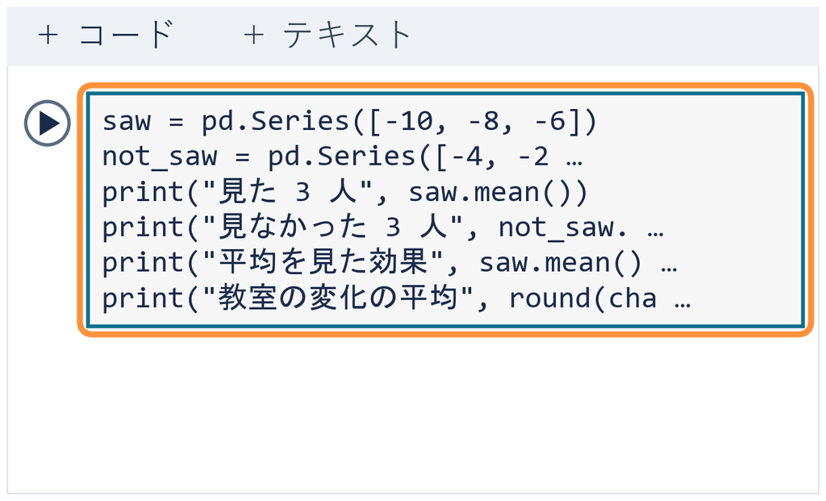

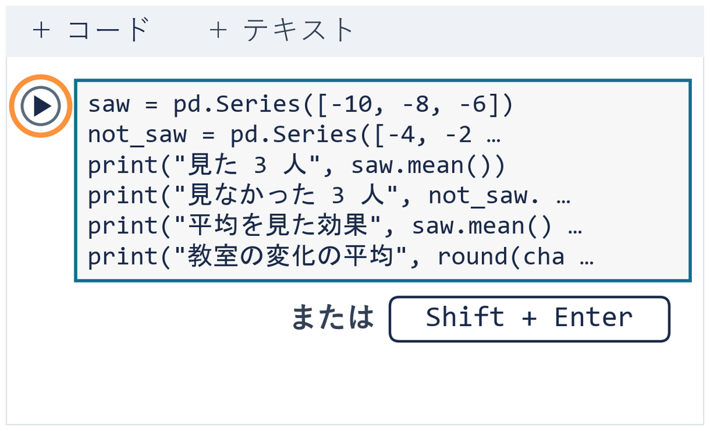

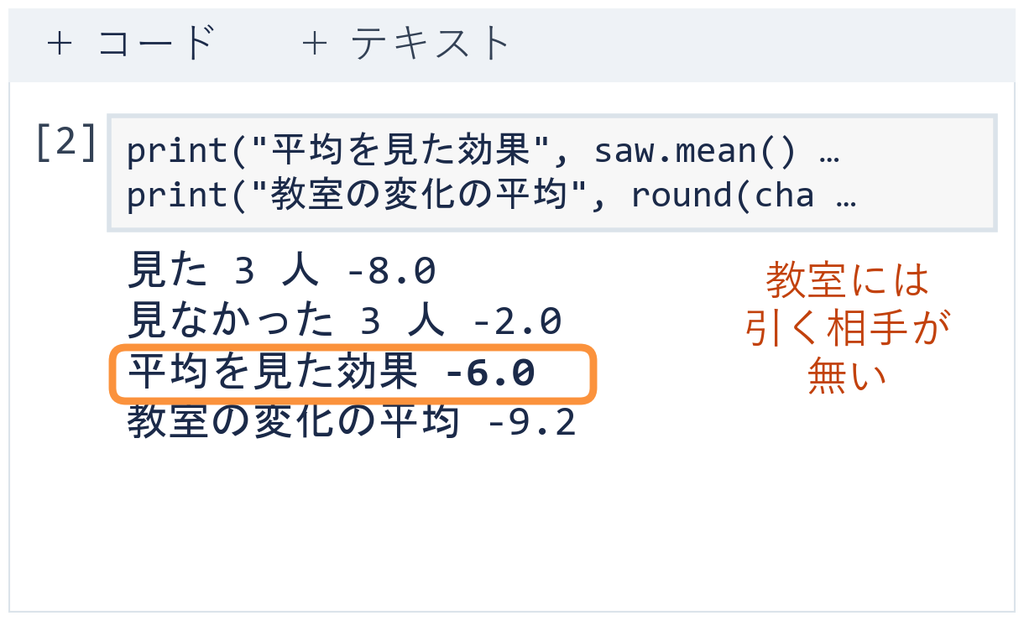

⏸ PAUSE 動画を止めて $2$ 分。4 行が出たら再生に戻る

## 演習 4-2 見なかった 3 人の変化

演習 4-2

見なかった 3 人も −8 なら、平均を見た効果はいくつか

```python
saw = pd.Series([-10, -8, -6])
not_saw = pd.Series([-4, -2, 0])
```

1. **先に考える**：ⓐ −6 ⓑ 0 ⓒ −8
2. **新しいセルで変える**：p.72 の 6 行を写し（コピー可）、  
   2 行目の 3 つの数を `-8, -8, -8` に
3. **終わり**：出る 4 行の 3 行目、`平均を見た効果` の数を読む

⏸ PAUSE 動画を止めて $3$ 分。数が出たら再生に戻る

## 演習 4-2 の答え

答えは ⓑ 0。$-8 - (-8) = 0$

[figure not shown]

見なかった人も同じだけ下げたなら、平均を見た効果は 0  
ただし、比べる相手が見た人とよく似ているときに限る

## 教室の結果の条件つきの一文

2026年度のデータ

第2回の型（条件・結果・範囲）に、教室の結果を入れる

**条件**第1回の教室・授業内。自己申告 R1 と R2 がそろった 50 行

**結果**上げた 15・下げた 31・同じ 4。変化の平均は −9.2

**範囲**見なかった人がいないので、平均を見たことが原因とは言えない

ニュースの「〜の後に平均が下がった、だから効果がある」も  
見なかった人と比べたかを確かめる

## 条件つきの一文を書く

書く

教室の結果を、条件・結果・範囲の 3 行で書く

**条件**どの集まりの数か（どの回・どの行）

**結果**何の数が、いくつだったか

**範囲**その数から、どこまで言えるか

1. **書く**：ノートの最後のテキストセルに、p.76 の形で
2. **終わり**：自分のノートの数で 3 行が書けたら

⏸ PAUSE 動画を止めて $3$ 分。3 行が書けたら再生に戻る

## 第3回 小課題の提出

STEP 1小課題ノート lecture03_beauty_open.ipynb を Colab で開く

STEP 2写経と演習のセルを上から実行し、答え欄（ⓐ〜ⓒ）も書く

STEP 3教室の結果を、条件つきの一文（3 行）で書く

STEP 4最後の提出前チェックのセルを ▶ し、全部 [ok] になるか確かめる

STEP 5ファイル → ダウンロード → .ipynb で保存して出す

提出先は manaba の「第3回 小課題」（締切も manaba に表示）  
開けないときは、条件つきの一文だけでも出す

## まとめ

- 同じ 22 は、いくつもの道から出る。記録に残るのは数だけ
- 識別：同じ数を生む説明を、データで 1 つに絞ること
- 比較群：A が起きなかった人の集まり。引き算で A の分を取り出す
- 因果推論には、見た人とよく似た比較群が要る
- 第1回の教室には見なかった人がいないので、原因は言えない

平均がどう動いても、誰がどう動いたか、なぜ動いたかは  
平均からは読めない